# Fitting the Highly Adaptive Lasso with `hal9001`

[Nima Hejazi](https://nimahejazi.org), [Jeremy Coyle](https://github.com/jeremyrcoyle), Rachael Phillips, Lars van der Laan

2023-11-13

## Preliminaries

```r
library(data.table)
library(ggplot2)
# simulation constants
set.seed(467392)
n_obs <- 500
n_covars <- 3

# make some training data
x <- replicate(n_covars, rnorm(n_obs))
y <- sin(x[, 1]) + sin(x[, 2]) + rnorm(n_obs, mean = 0, sd = 0.2)

# make some testing data
test_x <- replicate(n_covars, rnorm(n_obs))
test_y <- sin(x[, 1]) + sin(x[, 2]) + rnorm(n_obs, mean = 0, sd = 0.2)
```

Let’s look at simulated data:

```r
head(x)
```

```
##             [,1]       [,2]       [,3]
## [1,]  2.44102981 -0.4337909  0.4670282
## [2,] -1.21932335  0.3336395  0.8894277
## [3,] -0.40613567 -0.3869374  0.3474353
## [4,] -1.09760477 -1.4663219 -0.1173214
## [5,]  0.23710498  1.2565812  1.8049389
## [6,]  0.06810091 -0.7020905  0.9301941
```

```r
head(y)
```

```
## [1]  0.2372289 -0.6023415 -0.7569124 -1.8021339  1.0589707 -0.3373555
```

## Using the Highly Adaptive Lasso

```r
library(hal9001)
```

### Fitting the model

HAL uses the popular `glmnet` R package for the lasso step:

```r
hal_fit <- fit_hal(X = x, Y = y)
hal_fit$times
```

```
##                   user.self sys.self elapsed user.child sys.child
## enumerate_basis       0.005    0.000   0.006          0         0
## design_matrix         0.011    0.004   0.015          0         0
## reduce_basis          0.000    0.000   0.000          0         0
## remove_duplicates     0.000    0.000   0.000          0         0
## lasso                 1.548    0.010   1.566          0         0
## total                 1.565    0.014   1.587          0         0
```

### Summarizing the model

While the raw output object may be examined, it has (usually large) slots that make quick examination challenging. The `summary` method provides an interpretable table of basis functions with non-zero coefficients. All terms (i.e., including the terms with zero coefficient) can be included by setting `only_nonzero_coefs` to `FALSE` when calling `summary` on a `hal9001` model object.

```r
print(summary(hal_fit))
```

```
##
##
## Summary of non-zero coefficients is based on lambda of 0.002313645
##
##           coef
##  -1.413863e+00
##   3.425114e-01
##  -2.409479e-01
##  -2.028033e-01
##   1.987114e-01
##   1.532328e-01
##   1.461761e-01
##  -1.208921e-01
##  -1.138292e-01
##   9.474249e-02
##  -8.751248e-02
##   8.722109e-02
##  -7.747985e-02
##   7.636576e-02
##   7.091914e-02
##   6.507815e-02
##   6.363037e-02
##   5.949015e-02
##   5.825312e-02
##  -5.693372e-02
##  -4.930110e-02
##  -4.179132e-02
##   3.886159e-02
##  -3.491398e-02
##  -3.144890e-02
##   2.837083e-02
##  -2.649872e-02
##   2.111413e-02
##  -1.882364e-02
##   1.813560e-02
##  -1.803943e-02
##   1.773804e-02
##   1.695928e-02
##  -1.196234e-02
##  -1.176400e-02
```

[output cut: 92 more lines]

```
##  variables
##      x1-x2
##      x2-x3
##   x1-x2-x3
##      x1-x3
##                                                                         rule
##                            x1 >= -3.22417874337356 & x2 >= -3.03773683776349
##                            x2 >= -3.03773683776349 & x3 >= -3.28858811710025
##  x1 >= -3.22417874337356 & x2 >= -3.03773683776349 & x3 >= -3.28858811710025
##                            x1 >= -1.09376005644311 & x3 >= -3.28858811710025
##  cumulative_coefficient
##             -0.12102018
##             -0.21273647
##              0.11064487
##             -0.06914192
```

Note the length and width of these tables! The R environment might not be the optimal location to view the summary. Tip: Tables can be exported from R to LaTeX with the `xtable` R package. Here’s an example: `print(xtable(summary(fit)$table, type = "latex"), file = "haltbl_meow.tex")`.

### Obtaining model predictions

```r
# training sample prediction for HAL vs HAL9000
mse <- function(preds, y) {
  mean((preds - y)^2)
}

preds_hal <- predict(object = hal_fit, new_data = x)
mse_hal <- mse(preds = preds_hal, y = y)
mse_hal
```

```
## [1] 0.04499671
```

```r
oob_hal <- predict(object = hal_fit, new_data = test_x)
oob_hal_mse <- mse(preds = oob_hal, y = test_y)
oob_hal_mse
```

```
## [1] 1.801073
```

### Reducing basis functions

As described in Benkeser and van der Laan (2016), the HAL algorithm operates by first constructing a set of basis functions and subsequently fitting a Lasso model with this set of basis functions as the design matrix. Several approaches are considered for reducing this set of basis functions: 1. Removing duplicated basis functions (done by default in the `fit_hal` function), 2. Removing basis functions that correspond to only a small set of observations; a good rule of thumb is to scale with $\frac{1}{\sqrt{n}}$, and that is the default.

The second of these two options may be modified by specifying the `reduce_basis` argument to the `fit_hal` function:

```r
hal_fit_reduced <- fit_hal(X = x, Y = y, reduce_basis = 0.1)
hal_fit_reduced$times
```

```
##                   user.self sys.self elapsed user.child sys.child
## enumerate_basis       0.004    0.000   0.004          0         0
## design_matrix         0.014    0.000   0.015          0         0
## reduce_basis          0.001    0.000   0.000          0         0
## remove_duplicates     0.000    0.000   0.000          0         0
## lasso                 1.568    0.008   1.576          0         0
## total                 1.587    0.008   1.595          0         0
```

In the above, all basis functions with fewer than 10% of observations meeting the criterion imposed are automatically removed prior to the Lasso step of fitting the HAL regression. The results appear below

```r
summary(hal_fit_reduced)$table
```

```
##              coef
##  1: -1.346994e+00
##  2:  2.576756e-01
##  3: -2.434120e-01
##  4:  2.336262e-01
##  5:  1.706263e-01
##  6:  1.590289e-01
##  7: -1.461021e-01
##  8: -1.123958e-01
##  9: -9.993951e-02
## 10: -9.592210e-02
## 11:  7.420728e-02
## 12:  6.807883e-02
## 13: -4.751534e-02
## 14: -4.445773e-02
```

[output cut: 59 more lines]

Other approaches exist for reducing the set of basis functions *before* they are actually created, which is essential for most real-world applications with HAL. Currently, we provide this “pre-screening” via `num_knots` argument in `hal_fit`. The `num_knots` argument is akin to binning: it increases the coarseness of the approximation. `num_knots` allows one to specify the number of knot points used to generate the basis functions for each/all interaction degree(s). This reduces the total number of basis functions generated, and thus the size of the optimization problem, and it can dramatically decrease runtime. One can pass in a vector of length `max_degree` to `num_knots`, specifying the number of knot points to use by interaction degree for each basis function. Thus, one can specify if interactions of higher degrees (e.g., two- or three- way interactions) should be more coarse. Increasing the coarseness of more complex basis functions helps prevent a combinatorial explosion of basis functions, which can easily occur when basis functions are generated for all possible knot points. We will show an example with `num_knots` in the section that follows.

### Specifying smoothness of the HAL model

One might wish to enforce smoothness on the functional form of the HAL fit. This can be done using the `smoothness_orders` argument. Setting `smoothness_orders = 0` gives a piece-wise constant fit (via zero-order basis functions), allowing for discontinuous jumps in the function. This is useful if one does not want to assume any smoothness or continuity of the “true” function. Setting `smoothness_orders = 1` gives a piece-wise linear fit (via first-order basis functions), which is continuous and mostly differentiable. In general, `smoothness_orders = k` corresponds to a piece-wise polynomial fit of degree $k$. Mathematically, `smoothness_orders = k` corresponds with finding the best fit under the constraint that the total variation of the function’s $k^{\text{th}}$ derivative is bounded by some constant, which is selected with cross-validation.

Let’s see this in action.

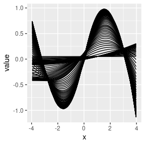

```r
set.seed(98109)
num_knots <- 100 # Try changing this value to see what happens.
n_covars <- 1
n_obs <- 250
x <- replicate(n_covars, runif(n_obs, min = -4, max = 4))
y <- sin(x[, 1]) + rnorm(n_obs, mean = 0, sd = 0.2)
ytrue <- sin(x[, 1])

hal_fit_0 <- fit_hal(
  X = x, Y = y, smoothness_orders = 0, num_knots = num_knots
)

hal_fit_smooth_1 <- fit_hal(
  X = x, Y = y, smoothness_orders = 1, num_knots = num_knots
)

hal_fit_smooth_2_all <- fit_hal(
  X = x, Y = y, smoothness_orders = 2, num_knots = num_knots,
  fit_control = list(cv_select = FALSE)
)

hal_fit_smooth_2 <- fit_hal(
  X = x, Y = y, smoothness_orders = 2, num_knots = num_knots
)

pred_0 <- predict(hal_fit_0, new_data = x)
pred_smooth_1 <- predict(hal_fit_smooth_1, new_data = x)
pred_smooth_2 <- predict(hal_fit_smooth_2, new_data = x)

pred_smooth_2_all <- predict(hal_fit_smooth_2_all, new_data = x)
dt <- data.table(x = as.vector(x))
dt <- cbind(dt, pred_smooth_2_all)
long <- melt(dt, id = "x")
ggplot(long, aes(x = x, y = value, group = variable)) +
  geom_line()
```

Comparing the mean squared error (MSE) between the predictions and the true (denoised) outcome, the first- and second- order smoothed HAL is able to recover from the coarseness of the basis functions caused by the small `num_knots` argument. Also, the HAL with second-order smoothness is able to fit the true function very well (as expected, since sin(x) is a very smooth function). The main benefit of imposing higher-order smoothness is that fewer knot points are required for a near-optimal fit. Therefore, one can safely pass a smaller value to `num_knots` for a big decrease in runtime without sacrificing performance.

```r
mean((pred_0 - ytrue)^2)
```

```
## [1] 0.007635298
```

```r
mean((pred_smooth_1 - ytrue)^2)
```

```
## [1] 0.002864562
```

```r
mean((pred_smooth_2 - ytrue)^2)
```

```
## [1] 0.001804221
```

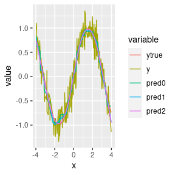

```r
dt <- data.table(
  x = as.vector(x),
  ytrue = ytrue,
  y = y,
  pred0 = pred_0,
  pred1 = pred_smooth_1,
  pred2 = pred_smooth_2
)
long <- melt(dt, id = "x")
ggplot(long, aes(x = x, y = value, color = variable)) +
  geom_line()
```

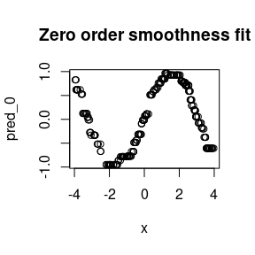

```r
plot(x, pred_0, main = "Zero order smoothness fit")
```

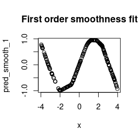

```r
plot(x, pred_smooth_1, main = "First order smoothness fit")
```

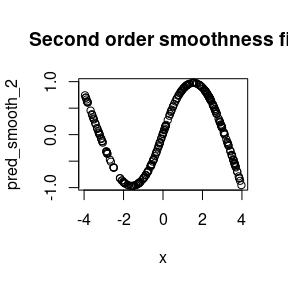

```r
plot(x, pred_smooth_2, main = "Second order smoothness fit")
```

```r
set.seed(98109)
n_covars <- 1
n_obs <- 250
x <- replicate(n_covars, runif(n_obs, min = -4, max = 4))
y <- sin(x[, 1]) + rnorm(n_obs, mean = 0, sd = 0.2)
ytrue <- sin(x[, 1])

hal_fit_0 <- fit_hal(
  X = x, Y = y, smoothness_orders = 0, num_knots = 100
)
hal_fit_smooth_1 <- fit_hal(
  X = x, Y = y, smoothness_orders = 1, num_knots = 100
)

hal_fit_smooth_2 <- fit_hal(
  X = x, Y = y, smoothness_orders = 2, num_knots = 100
)

pred_0 <- predict(hal_fit_0, new_data = x)
pred_smooth_1 <- predict(hal_fit_smooth_1, new_data = x)
pred_smooth_2 <- predict(hal_fit_smooth_2, new_data = x)
```

```r
mean((pred_0 - ytrue)^2)
```

```
## [1] 0.007635298
```

```r
mean((pred_smooth_1 - ytrue)^2)
```

```
## [1] 0.002864562
```

```r
mean((pred_smooth_2 - ytrue)^2)
```

```
## [1] 0.001859842
```

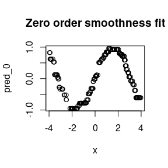

```r
plot(x, pred_0, main = "Zero order smoothness fit")
```

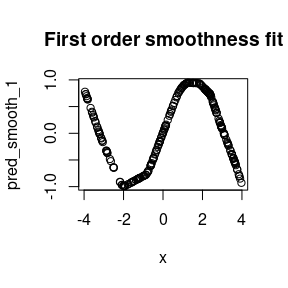

```r
plot(x, pred_smooth_1, main = "First order smoothness fit")
```

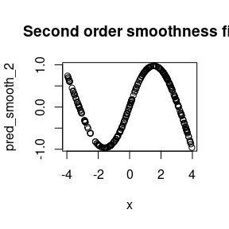

```r
plot(x, pred_smooth_2, main = "Second order smoothness fit")
```

### Formula interface

One might wish to specify the functional form of the HAL fit further. This can be done using the formula interface. Specifically, the formula interface allows one to specify monotonicity constraints on components of the HAL fit. It also allows one to specify exactly which basis functions (e.g., interactions) one wishes to model. The `formula_hal` function generates a `formula` object from a user-supplied character string, and this `formula` object contains the necessary specification information for `fit_hal` and `glmnet`. The `formula_hal` function is intended for use within `fit_hal`, and the user-supplied character string is inputted into `fit_hal`. Here, we call `formula_hal` directly for illustrative purposes.

```r
set.seed(98109)
num_knots <- 100

n_obs <- 500
x1 <- runif(n_obs, min = -4, max = 4)
x2 <- runif(n_obs, min = -4, max = 4)
A <- runif(n_obs, min = -4, max = 4)
X <- data.frame(x1 = x1, x2 = x2, A = A)
Y <- rowMeans(sin(X)) + rnorm(n_obs, mean = 0, sd = 0.2)
```

We can specify an additive model in a number of ways.

The formula below includes the outcome, but `formula_hal` doesn’t fit a HAL model, and doesn’t need the outcome (actually everything before “$\tilde$” is ignored in `formula_hal`). This is why `formula_hal` takes the input `X` matrix of covariates, and not `X` and `Y`. In what follows, we include formulas with and without “y” in the character string.

```r
# The `h` function is used to specify the basis functions for a given term
# h(x1) generates one-way basis functions for the variable x1
# This is an additive model:
formula <- ~ h(x1) + h(x2) + h(A)
# We can actually evaluate the h function as well. We need to specify some tuning parameters in the current environment:
smoothness_orders <- 0
num_knots <- 10
# It will look in the parent environment for `X` and the above tuning parameters
form_term <- h(x1) + h(x2) + h(A)
form_term$basis_list[[1]]
```

```
## $cols
## [1] 1
##
## $cutoffs
## [1] -3.971502
##
## $orders
## [1] 0
```

```r
# We don't need the variables in the parent environment if we specify them directly:
rm(smoothness_orders)
rm(num_knots)
# `h` excepts the arguments `s` and `k`. `s` stands for smoothness and is equivalent to smoothness_orders in use. `k` specifies the number of knots. `
form_term_new <- h(x1, s = 0, k = 10) + h(x2, s = 0, k = 10) + h(A, s = 0, k = 10)
# They are the same!
length(form_term_new$basis_list) == length(form_term$basis_list)
```

```
## [1] TRUE
```

```r
# To evaluate a unevaluated formula object like:
formula <- ~ h(x1) + h(x2) + h(A)
# we can use the formula_hal function:
formula <- formula_hal(
  ~ h(x1) + h(x2) + h(A),
  X = X, smoothness_orders = 1, num_knots = 10
)
# Note that the arguments smoothness_orders and/or num_knots will not be used if `s` and/or `k` are specified in `h`.
formula <- formula_hal(
  Y ~ h(x1, k = 1) + h(x2, k = 1) + h(A, k = 1),
  X = X, smoothness_orders = 1, num_knots = 10
)
```

The `.` argument. We can generate an additive model for all or a subset of variables using the `.` variable and `.` argument of `h`. By default, `.` in `h(.)` is treated as a wildcard and basis functions are generated by replacing the `.` with all variables in `X`.

```r
smoothness_orders <- 1
num_knots <- 5
# A additive model
colnames(X)
```

```
## [1] "x1" "x2" "A"
```

```r
# Shortcut:
formula1 <- h(.)
# Longcut:
formula2 <- h(x1) + h(x2) + h(A)
# Same number of basis functions
length(formula1$basis_list) == length(formula2$basis_list)
```

```
## [1] TRUE
```

```r
# Maybe we only want an additive model for x1 and x2
# Use the `.` argument
formula1 <- h(., . = c("x1", "x2"))
formula2 <- h(x1) + h(x2)
length(formula1$basis_list) == length(formula2$basis_list)
```

```
## [1] TRUE
```

We can specify interactions as follows.

```r
#  Two way interactions
formula1 <- h(x1) + h(x2) + h(A) + h(x1, x2)
formula2 <- h(.) + h(x1, x2)
length(formula1$basis_list) == length(formula2$basis_list)
```

```
## [1] TRUE
```

```r
#
formula1 <- h(.) + h(x1, x2) + h(x1, A) + h(x2, A)
formula2 <- h(.) + h(., .)
length(formula1$basis_list) == length(formula2$basis_list)
```

```
## [1] TRUE
```

```r
#  Three way interactions
formula1 <- h(.) + h(., .) + h(x1, A, x2)
formula2 <- h(.) + h(., .) + h(., ., .)
length(formula1$basis_list) == length(formula2$basis_list)
```

```
## [1] TRUE
```

Sometimes, one might want to build an additive model, but include all two-way interactions with one variable (e.g., treatment “A”). This can be done in a variety of ways. The `.` argument allows you to specify a subset of variables.

```r
# Write it all out
formula <- h(x1) + h(x2) + h(A) + h(A, x1) + h(A, x2)


# Use the "h(.)" which stands for add all additive terms and then manually add
# interactions
formula <- y ~ h(.) + h(A, x1) + h(A, x2)



# Use the "wildcard" feature for when "." is included in the "h()" term. This
# useful when you have many variables and do not want to write out every term.
formula <- h(.) + h(A, .)


formula1 <- h(A, x1)
formula2 <- h(A, ., . = c("x1"))
length(formula1$basis_list) == length(formula2$basis_list)
```

```
## [1] TRUE
```

A key feature of the HAL formula is **monotonicity constraints**. Specifying these constraints is achieved by specifying the `monotone` argument of `h`. Note if smoothness_orders = 0 then this is a monotonicity constrain on the function, but if if smoothness_orders = 1 then this is a monotonicity constraint on the function’s derivative (e.g. a convexity constraint). We can also specify that certain terms are not penalized in the LASSO/glmnet using the `pf` argument of `h` (stands for penalty factor).

```r
# An additive monotone increasing model
formula <- formula_hal(
  y ~ h(., monotone = "i"), X,
  smoothness_orders = 0, num_knots = 100
)

# An additive unpenalized monotone increasing model (NPMLE isotonic regressio)
# Set the penalty factor argument `pf` to remove L1 penalization
formula <- formula_hal(
  y ~ h(., monotone = "i", pf = 0), X,
  smoothness_orders = 0, num_knots = 100
)

# An additive unpenalized convex model (NPMLE convex regressio)
# Set the penalty factor argument `pf` to remove L1 penalization
# Note the second term is equivalent to adding unpenalized and unconstrained main-terms (e.g. main-term glm)
formula <- formula_hal(
  ~ h(., monotone = "i", pf = 0, k = 200, s = 1) + h(., monotone = "none", pf = 0, k = 1, s = 1), X
)

# A bi-additive monotone decreasing model
formula <- formula_hal(
  ~ h(., monotone = "d") + h(., ., monotone = "d"), X,
  smoothness_orders = 1, num_knots = 100
)
```

The penalization feature can be used to reproduce glm

```r
# Additive glm
# One knot (at the origin) and first order smoothness
formula <- h(., s = 1, k = 1, pf = 0)
# Running HAL with this formula will be equivalent to running glm with the formula Y ~ .

# intraction glm
formula <- h(., ., s = 1, k = 1, pf = 0) + h(., s = 1, k = 1, pf = 0)
# Running HAL with this formula will be equivalent to running glm with the formula Y ~ .^2
```

Now, that we’ve illustrated the options with `formula_hal`, let’s show how to fit a HAL model with the specified formula.

```r
# get formula object
fit <- fit_hal(
  X = X, Y = Y, formula = ~ h(.), smoothness_orders = 1, num_knots = 100
)
print(summary(fit), 10) # prints top 10 rows, i.e., highest absolute coefs
```

```
##
## Summary of top 10 non-zero coefficients is based on lambda of 0.0005376299
##
##        coef                                term
##   0.7473715                         (Intercept)
##  -0.3081866   [ I(A >= -3.978)*(A - -3.978)^1 ]
##  -0.2894577 [ I(x2 >= -3.992)*(x2 - -3.992)^1 ]
##  -0.2811616   [ I(x1 >= 1.172)*(x1 - 1.172)^1 ]
##  -0.2463477 [ I(x1 >= -3.972)*(x1 - -3.972)^1 ]
##  -0.2405977   [ I(x2 >= 1.638)*(x2 - 1.638)^1 ]
##   0.2092225   [ I(x1 >= -1.45)*(x1 - -1.45)^1 ]
##   0.2078703 [ I(x2 >= -1.293)*(x2 - -1.293)^1 ]
##  -0.2039605     [ I(A >= 1.384)*(A - 1.384)^1 ]
##   0.1993688   [ I(A >= -1.356)*(A - -1.356)^1 ]
##
##
##  Summary of aggregated marginal and interaction regions:
##
## NULL
```

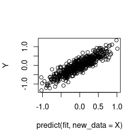

```r
plot(predict(fit, new_data = X), Y)
```

## References

Benkeser, David, and Mark J van der Laan. 2016. “The Highly Adaptive Lasso Estimator.” In *2016 IEEE International Conference on Data Science and Advanced Analytics (DSAA)*. IEEE. https://doi.org/10.1109/dsaa.2016.93.

Coyle, Jeremy R, Nima S Hejazi, and Mark J van der Laan. n.d. “`hal9001`: The Scalable Highly Adaptive Lasso.” https://doi.org/10.5281/zenodo.3558313.

Friedman, Jerome, Trevor Hastie, and Rob Tibshirani. 2010. “Regularization Paths for Generalized Linear Models via Coordinate Descent.” *Journal of Statistical Software* 33 (1): 1.

Hejazi, Nima S, Jeremy R Coyle, and Mark J van der Laan. 2020. “hal9001: Scalable Highly Adaptive Lasso Regression in R.” *Journal of Open Source Software* 5 (53): 2526. https://doi.org/10.21105/joss.02526.

van der Laan, Mark J. 2017. “Finite Sample Inference for Targeted Learning.” https://arxiv.org/abs/1708.09502.